# Modeling Inbound Tourism

## Observations and Insights

In this particular project we try to quantify the impact of some of the key variables in the number of tourims of a country of Organisation for Economic Co-operation and Development (OECD).

In this project, we start with the hypothesis that tourism is a function of distance, cultural offer, natural resources, government participation in tourism, the nation's security, price competitiveness, infrastructure, and visa requirements. Is for this motive, we estimate distance and used the index of the Travel & Tourism Competitiveness Report 2019 (WEF) by the World Economic Forum.

We used a different approach to estimate the model, explaining the number of tourism in a country. We compared the use of Linear Models and Pooled coefficient estimator for panel data.

As a result, we observed that the variable that is more explained is the cultural offer. However, infrastructure service and natural resources are variables that are involved in the number of tourism. When we used aleatory samples from regression, this variable could help to predict the number of tourism.

### Sep up dependecies

```python
import pandas as pd
import numpy as np
import os
import geopandas as gpd
import pymongo
import matplotlib.pyplot as plt
from shapely.geometry import Point
```

```python
#!pip install linearmodels
```

```python
#dependecies to have linear regress simple
import scipy.stats as st
from scipy.stats import linregress

#dependecies to have linear model
from sklearn import linear_model
from sklearn.model_selection import train_test_split
from sklearn.metrics import mean_squared_error, r2_score

#Dependecies for panel data models
from linearmodels import PanelOLS
from linearmodels.panel import PooledOLS
from linearmodels.panel import RandomEffects
from linearmodels.panel import compare
```

#### Definition to transform, get data

```python
#Getting indexes of WEF collection
def IndexWEF(country, year):
    try:
        #Get only the information of the target country
        X=WEFdata[country]
        #For each country there is only three values for the following year [WEF update index each two year for this only use aviable info]
        X.dropna(inplace=True)
        if year==2015 or year==2014:
            i=0
            yearInfo=2015
        elif year==2017 or year==2016:
            i=1
            yearInfo=2017
        elif year==2019 or year==2018:
            i=2
            yearInfo=2019


        #Get the value info
        results=list(X[list(X.index)[0]][i][str(yearInfo)].values())

        #Store the info in the following variables
        cultural=results[0]
        government_prioritization=results[1]
        segurity_homocide=results[2]
        segurity_terrorism=results[3]
        natural_resources=results[4]
        price_competitiveness=results[5]
        service_infrastructure=results[6]
        visa_requirements=results[7]

    except:
        #if the country is not found or is diferent the year return 'na'
        cultural=np.nan
        government_prioritization=np.nan
        segurity_homocide=np.nan
        segurity_terrorism=np.nan
        natural_resources=np.nan
        price_competitiveness=np.nan
        service_infrastructure=np.nan
        visa_requirements=np.nan

    #return variables
    return cultural, government_prioritization, segurity_homocide, segurity_terrorism, natural_resources, price_competitiveness, service_infrastructure, visa_requirements
```

```python
#definir calcular la distancia
def DistancePoint(country1,country2):
    try:
        #find coordenates for country1
        objectSerch1=coordenateDF.loc[coordenateDF['name']==country1]
        latitude1=float(objectSerch1['latitude'])
        longitud1=float(objectSerch1['longitude'])
        point1=Point(longitud1,latitude1)

        #find coordenates for country1
        objectSerch2=coordenateDF.loc[coordenateDF['name']==country2]
        latitude2=float(objectSerch2['latitude'])
        longitud2=float(objectSerch2['longitude'])
        point2=Point(longitud2,latitude2)


        #GeoDataFrame
        points_df = gpd.GeoDataFrame({'geometry': [point1, point2]}, crs='EPSG:4326')
        points_df = points_df.to_crs('EPSG:4326')




        result=float(points_df['geometry'][0].distance(points_df['geometry'][1])*100)
    except:
        result=np.nan

    return result
```

```python
def wavg(country):
    Country=tourismData.loc[tourismData['Country']==country]

    iv=np.average(Country['Inbound Visitors'], weights=Country['Inbound Visitors'])
    distance=np.average(Country['Distance'], weights=Country['Inbound Visitors'])
    cultural=np.average(Country['Cultural'], weights=Country['Inbound Visitors'])
    gp=np.average(Country['Government_prioritization'], weights=Country['Inbound Visitors'])
    sh=np.average(Country['Segurity_homocide'], weights=Country['Inbound Visitors'])
    st=np.average(Country['Segurity_terrorism'], weights=Country['Inbound Visitors'])
    nr=np.average(Country['Natural_resources'], weights=Country['Inbound Visitors'])
    pc=np.average(Country['Price_competitiveness'], weights=Country['Inbound Visitors'])
    si=np.average(Country['Service_infrastructure'], weights=Country['Inbound Visitors'])
    vr=np.average(Country['Visa_requirements'], weights=Country['Inbound Visitors'])

    return iv, distance, cultural, gp, sh, st, nr, pc, si, vr
```

```python
DistancePoint('Australia','Austria')
```

```
nan
```

```python
def graphRegressSimple(x_values,y_values):

    #Get the variables to test hipotesis

    x_values=x_values
    y_values=y_values
    name_x=x_values.name
    name_y=y_values.name


    #Estamimate linear regression simple
    (slope, intercept, rvalue, pvalue, stderr) =linregress(x_values, y_values)
    regress_values = x_values * slope + intercept
    if intercept<0:
        string='-'
    else:
        string='+'
    line_eq = "y = " + str(round(slope,2)) + f'*x {string}'  + str(round(intercept,2))
    r_value=rvalue

    #Construct graph sacatter

    plt.scatter(x_values,y_values, color='black', marker='o', facecolor='steelblue')
    plt.plot(x_values, regress_values, color='red')
    plt.annotate(f'{line_eq} with R={round(r_value,2)} and p-value:{round(pvalue,4)}',(x_values.min(),y_values.max()), fontsize='x-large', color="black", alpha=1)
    plt.title(f'{name_y} vs {name_x}', fontsize='xx-large')
    plt.grid(lw=0.2)
    plt.ylabel(name_y, fontsize='large')
    plt.xlabel(name_x, fontsize='large')


    return plt.show()
```

### Reading tourismDB collection for Dataset

Using the results of the previous project, the following is the Extract, Transform, and Load the information to be used estimating model.

```python
#Gettin connection with data base
conn = 'mongodb+srv://user1:1234@cluster0.oi7pu.mongodb.net/turismo?retryWrites=true&w=majority'
client = pymongo.MongoClient(conn)
db = client['tourismDB']
collection=db['tourismDB']
coordenates=db['coordenates']
WEF=db['WEF']
```

```python
#getting dataframes
data=pd.DataFrame(collection.find())
tourism_df = pd.DataFrame.from_dict(collection.find())
tourism_df.drop(axis=1, labels='_id', inplace=True)
coordenateDF=pd.DataFrame(coordenates.find())
WEFdata=pd.DataFrame(WEF.find())
client.close()
```

```python
#New Tourism_df to append a row per each year
column_names = ['Country', 'Year', 'Inbound Country', 'Inbound Visitors', 'Outbound Country', 'Outbound Visitors']
tourism_new_df = pd.DataFrame(columns=column_names)
```

```python
#Structure for panel data
for row in tourism_df.itertuples(index=False):
    #print(row.name)
    #Iterating over years to create a DataFrame to be appended to new
    for x in range(5):     #Number of top markets and top destinations for each country (row.name)
        #print(row.top_destinations)
        for i, year in enumerate(row.years): #Each country's top market and top destination has five values (one per year)
            #print(row.top_destinations.keys())
            try:
                my_dict = {'Country':row.name,
                                        'Year': int(year),
                                 'Inbound Country': list(row.top_markets.keys())[x],
                                  'Inbound Visitors': list(row.top_markets.values())[x][i],
                                  'Outbound Country':list(row.top_destinations.keys())[x],
                                  'Outbound Visitors':list(row.top_destinations.values())[x][i]
                                  }
                #print(temp_df)
                tourism_new_df = tourism_new_df.append(pd.DataFrame([my_dict]), ignore_index=True)

                #print(tourism_new_df)
            except IndexError:
                continue

tourism_new_df.head()
```

|  | Country | Year | Inbound Country | Inbound Visitors | Outbound Country | Outbound Visitors |
| --- | --- | --- | --- | --- | --- | --- |
| 0 | Australia | 2014 | China | 773.7 | New Zealand | 1185.6 |
| 1 | Australia | 2015 | China | 936.0 | New Zealand | 1224.8 |
| 2 | Australia | 2016 | China | 1145.7 | New Zealand | 1292.6 |
| 3 | Australia | 2017 | China | 1259.1 | New Zealand | 1411.6 |
| 4 | Australia | 2018 | China | 1421.6 | New Zealand | 1419.0 |

## Model of the project

In this project, we start with the hypothesis that tourism is a function of distance, cultural offer, natural resources, government participation in tourism, the nation's security, price competitiveness, infrastructure, and visa requirements. Is for this motive, we estimate distance and used the index of the Travel & Tourism Competitiveness Report 2019 (WEF) by the World Economic Forum. The following is tranform in panel data the information to be used to determinate the funtion:

$Tourism $=$f$ ($distance$,$culture$,$GP$,$SH$,$ST$,$NR$,$PC$,$SI$,$VR$)

where

$distance$= Indicate how far are two contries by kilometers

$culture$= The index of cultural resources and business 7 indicate more offer of cultural resources while 1 indicate less offer of cultural resources

$GP$= The index Government prioritization of the travel & tourism industry 7 indicate top priority while 1 indicate no priority at all

$SH$= The index Homicide rate 7 less number of homocide per 100,000 population while 1 less number of homocide per 100,000 population

$ST$= The Index of terrorism incidence 7 indicate no attack while 1 most attacks or casualities

$NR$= Natural Resources 7 indicate more offer of natural resources while 1 indicate less offer

$PC$= Price competitiveness 7 indicate more price competitiviness while 1 less price competitiviness

$SI$= The transport infraestructura 7 indicate more developet infraestructure while 1 less develop infraestructure

$VR$= Visa requirements two countries 7 less requirements while 1 more requirements

```python
#Integrate Distance
newColumn=[]
for i in range(len(tourism_new_df)):
    country1=tourism_new_df['Country'][i]
    country2=tourism_new_df['Inbound Country'][i]
    newColumn.append(DistancePoint(country1,country2))


tourism_new_df['Distance']=newColumn
```

```python
#Integrate index in the Panel Data

NewCultural=[]
NewGovernment_prioritization=[]
NewSegurity_homocide=[]
NewSegurity_terrorism=[]
NewNatural_resources=[]
NewPrice_competitiveness=[]
NewService_infrastructure=[]
NewVisa_requirements=[]

for i in range(len(tourism_new_df)):
    country=tourism_new_df['Country'][i]
    year=tourism_new_df['Year'][i]

    #Use Index of WEF

    cultural, government_prioritization, segurity_homocide, segurity_terrorism, natural_resources, price_competitiveness, service_infrastructure, visa_requirements=IndexWEF(country, year)


    NewCultural.append(cultural)
    NewGovernment_prioritization.append(government_prioritization)
    NewSegurity_homocide.append(segurity_homocide)
    NewSegurity_terrorism.append(segurity_terrorism)
    NewNatural_resources.append(natural_resources)
    NewPrice_competitiveness.append(price_competitiveness)
    NewService_infrastructure.append(service_infrastructure)
    NewVisa_requirements.append(visa_requirements)

#Adding for Panel Data
tourism_new_df['Cultural']=NewCultural
tourism_new_df['Government_prioritization']=NewGovernment_prioritization
tourism_new_df['Segurity_homocide']=NewSegurity_homocide
tourism_new_df['Segurity_terrorism']=NewSegurity_terrorism
tourism_new_df['Natural_resources']=NewNatural_resources
tourism_new_df['Price_competitiveness']=NewPrice_competitiveness
tourism_new_df['Service_infrastructure']=NewService_infrastructure
tourism_new_df['Visa_requirements']=NewVisa_requirements





tourism_new_df.head()
```

|  | Country | Year | Inbound Country | Inbound Visitors | Outbound Country | Outbound Visitors | Distance | Cultural | Government_prioritization | Segurity_homocide | Segurity_terrorism | Natural_resources | Price_competitiveness | Service_infrastructure | Visa_requirements |
| --- | --- | --- | --- | --- | --- | --- | --- | --- | --- | --- | --- | --- | --- | --- | --- |
| 0 | Australia | 2014 | China | 773.7 | New Zealand | 1185.6 | 6791.596681 | 5.134926 | 5.675631 | 0.077058 | 7.000000 | 5.305912 | 3.064364 | 5.442437 | 2.171629 |
| 1 | Australia | 2015 | China | 936.0 | New Zealand | 1224.8 | 6791.596681 | 5.134926 | 5.675631 | 0.077058 | 7.000000 | 5.305912 | 3.064364 | 5.442437 | 2.171629 |
| 2 | Australia | 2016 | China | 1145.7 | New Zealand | 1292.6 | 6791.596681 | 4.954463 | 5.762525 | 0.088446 | 6.834166 | 5.212771 | 3.822125 | 6.061304 | 3.502627 |
| 3 | Australia | 2017 | China | 1259.1 | New Zealand | 1411.6 | 6791.596681 | 4.954463 | 5.762525 | 0.088446 | 6.834166 | 5.212771 | 3.822125 | 6.061304 | 3.502627 |
| 4 | Australia | 2018 | China | 1421.6 | New Zealand | 1419.0 | 6791.596681 | 4.379572 | 5.896900 | 0.065930 | 6.954147 | 5.502131 | 4.434410 | 6.055063 | 3.502627 |

```python
tourism_new_df.describe()
```

|  | Inbound Visitors | Outbound Visitors | Distance | Cultural | Government_prioritization | Segurity_homocide | Segurity_terrorism | Natural_resources | Price_competitiveness | Service_infrastructure | Visa_requirements |
| --- | --- | --- | --- | --- | --- | --- | --- | --- | --- | --- | --- |
| count | 645.000000 | 645.000000 | 580.000000 | 620.000000 | 620.000000 | 620.000000 | 620.000000 | 620.000000 | 620.000000 | 620.000000 | 620.000000 |
| mean | 1775.147320 | 1698.554456 | 3586.315598 | 3.309564 | 5.186869 | 0.175955 | 6.445180 | 3.848261 | 4.336542 | 5.464036 | 1.876391 |
| std | 3538.810099 | 3453.001000 | 5288.792393 | 1.686433 | 0.815165 | 0.325337 | 1.357961 | 0.937269 | 0.656591 | 0.780306 | 0.792356 |
| min | 0.000000 | 0.000000 | 107.095426 | 1.328823 | 3.010296 | 0.017012 | 1.000000 | 2.217452 | 2.567043 | 3.585026 | 0.420315 |
| 25% | 203.000000 | 217.123000 | 671.322454 | 2.120717 | 4.681455 | 0.069029 | 6.789500 | 2.980953 | 3.880156 | 4.851186 | 1.611208 |
| 50% | 793.000000 | 793.000000 | 1471.498236 | 2.870020 | 5.162483 | 0.084423 | 6.980000 | 4.056809 | 4.378550 | 5.477859 | 1.681261 |
| 75% | 2013.000000 | 1824.457365 | 3937.837872 | 4.102554 | 5.805417 | 0.112084 | 7.000000 | 4.602719 | 4.678371 | 6.061304 | 1.681261 |
| max | 36449.000000 | 36449.000000 | 28161.375771 | 6.850000 | 6.688822 | 2.157618 | 7.000000 | 5.502131 | 5.783301 | 6.827937 | 4.693520 |

```python
tourismData=tourism_new_df.dropna(axis=0, how='any')
tourismData.describe()
```

|  | Inbound Visitors | Outbound Visitors | Distance | Cultural | Government_prioritization | Segurity_homocide | Segurity_terrorism | Natural_resources | Price_competitiveness | Service_infrastructure | Visa_requirements |
| --- | --- | --- | --- | --- | --- | --- | --- | --- | --- | --- | --- |
| count | 555.000000 | 555.000000 | 555.000000 | 555.000000 | 555.000000 | 555.000000 | 555.000000 | 555.000000 | 555.000000 | 555.000000 | 555.000000 |
| mean | 1820.988979 | 1756.122765 | 3493.049003 | 3.374842 | 5.189160 | 0.174612 | 6.425894 | 3.880417 | 4.312481 | 5.491249 | 1.884350 |
| std | 3761.595450 | 3689.166194 | 5370.371017 | 1.704223 | 0.819460 | 0.336005 | 1.360142 | 0.910937 | 0.663131 | 0.783761 | 0.827570 |
| min | 0.000000 | 0.000000 | 107.095426 | 1.328823 | 3.010296 | 0.017012 | 1.000000 | 2.217452 | 2.567043 | 3.585026 | 0.420315 |
| 25% | 196.914500 | 212.372236 | 620.375852 | 2.164253 | 4.681455 | 0.069029 | 6.745000 | 2.994851 | 3.858186 | 4.935522 | 1.611208 |
| 50% | 763.000000 | 715.603000 | 1305.064998 | 2.870020 | 5.173846 | 0.084423 | 6.978500 | 4.059836 | 4.366998 | 5.607887 | 1.681261 |
| 75% | 1986.149000 | 1845.918500 | 3006.488475 | 4.704627 | 5.805417 | 0.107926 | 7.000000 | 4.600719 | 4.678143 | 6.079820 | 1.681261 |
| max | 36449.000000 | 36449.000000 | 28161.375771 | 6.850000 | 6.688822 | 2.157618 | 7.000000 | 5.502131 | 5.783301 | 6.827937 | 4.693520 |

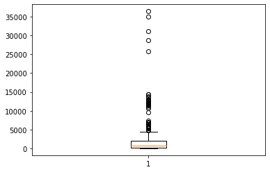

```python
plt.boxplot(tourismData['Inbound Visitors'])
plt.show()
```

```python
quartiles = tourismData['Inbound Visitors'].quantile([.25,.5,.75])
lowerq = quartiles[0.25]
upperq = quartiles[0.75]
iqr = upperq-lowerq
lower_bound = lowerq - (1.5*iqr)
upper_bound = upperq + (1.5*iqr)

output=f'''
    -------------------------------------------------------
    The lower quartile of Inbound Visitors is: {round(lowerq,2)}

    The upper quartile of Inbound Visitors is: {round(upperq,2)}

    The interquartile range of Inbound Visitors is: {round(iqr,2)}

    The the median of Inbound Visitors is: {round(quartiles[0.5],2)}

    Values below {round(lower_bound,2)} could be outliers.

    Values above {round(upper_bound,2)} could be outliers.

    '''
print(output)
```

```
    -------------------------------------------------------
    The lower quartile of Inbound Visitors is: 196.91

    The upper quartile of Inbound Visitors is: 1986.15

    The interquartile range of Inbound Visitors is: 1789.23

    The the median of Inbound Visitors is: 763.0

    Values below -2486.94 could be outliers.

    Values above 4670.0 could be outliers.
```

```python
tourismData=tourismData.loc[tourismData['Inbound Visitors']<upper_bound]
```

```python
tourismData.describe()
```

|  | Inbound Visitors | Outbound Visitors | Distance | Cultural | Government_prioritization | Segurity_homocide | Segurity_terrorism | Natural_resources | Price_competitiveness | Service_infrastructure | Visa_requirements |
| --- | --- | --- | --- | --- | --- | --- | --- | --- | --- | --- | --- |
| count | 514.000000 | 514.000000 | 514.000000 | 514.000000 | 514.000000 | 514.000000 | 514.000000 | 514.000000 | 514.000000 | 514.000000 | 514.000000 |
| mean | 996.707877 | 1194.379882 | 3675.061794 | 3.168657 | 5.182748 | 0.178776 | 6.464673 | 3.821608 | 4.336243 | 5.448864 | 1.925763 |
| std | 1011.587759 | 1802.223165 | 5537.904290 | 1.579651 | 0.842829 | 0.347785 | 1.376783 | 0.908534 | 0.666789 | 0.791423 | 0.832388 |
| min | 0.000000 | 0.000000 | 107.095426 | 1.328823 | 3.010296 | 0.017012 | 1.000000 | 2.217452 | 2.567043 | 3.585026 | 0.420315 |
| 25% | 181.255310 | 196.730000 | 620.375852 | 2.129965 | 4.673936 | 0.065930 | 6.798000 | 2.982391 | 3.863679 | 4.750254 | 1.611208 |
| 50% | 588.300000 | 596.416000 | 1451.229152 | 2.817357 | 5.151120 | 0.084063 | 6.981145 | 3.976185 | 4.383614 | 5.489360 | 1.681261 |
| 75% | 1523.525750 | 1532.640514 | 3893.758698 | 3.510885 | 5.805417 | 0.112084 | 7.000000 | 4.495361 | 4.678371 | 6.061304 | 1.681261 |
| max | 4464.000000 | 13572.692388 | 28161.375771 | 6.850000 | 6.688822 | 2.157618 | 7.000000 | 5.502131 | 5.783301 | 6.827937 | 4.693520 |

```python
#Estimate mean by contry
MultilinearData=pd.DataFrame(tourismData.groupby(['Country']).agg('mean'))
```

```python
#Estimate weighted average by country
Country=[]
NewIV=[]
NewDistance=[]
NewCultural=[]
NewGovernment_prioritization=[]
NewSegurity_homocide=[]
NewSegurity_terrorism=[]
NewNatural_resources=[]
NewPrice_competitiveness=[]
NewService_infrastructure=[]
NewVisa_requirements=[]

for country in tourismData['Country']:


    #Estimate weighted average by country

    iv, distance, cultural, government_prioritization, segurity_homocide, segurity_terrorism, natural_resources, price_competitiveness, service_infrastructure, visa_requirements=wavg(country)
    NewIV.append(iv)
    Country.append(country)
    NewDistance.append(distance)
    NewCultural.append(cultural)
    NewGovernment_prioritization.append(government_prioritization)
    NewSegurity_homocide.append(segurity_homocide)
    NewSegurity_terrorism.append(segurity_terrorism)
    NewNatural_resources.append(natural_resources)
    NewPrice_competitiveness.append(price_competitiveness)
    NewService_infrastructure.append(service_infrastructure)
    NewVisa_requirements.append(visa_requirements)

#Adding for Panel Data
MultilinearDataAvgW=pd.DataFrame({
    'Country':Country,
    'Inbound Visitors':NewIV,
    'Distance':NewDistance,
    'Cultural':NewCultural,
    'Government_prioritization':NewGovernment_prioritization,
    'Segurity_homocide':NewSegurity_homocide,
    'Segurity_terrorism':NewSegurity_terrorism,
    'Natural_resources':NewNatural_resources,
    'Price_competitiveness':NewPrice_competitiveness,
    'Service_infrastructure':NewService_infrastructure,
    'Visa_requirements':NewVisa_requirements

})

MultilinearDataAvgW.drop_duplicates(keep='first', inplace=True)
MultilinearDataAvgW.set_index('Country', inplace=True)
```

## Linear Regressions

### Distance as explicative variable

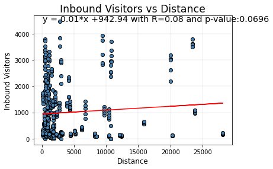

```
--------------------------------------------------------------------------------------
Mean of Variable
```

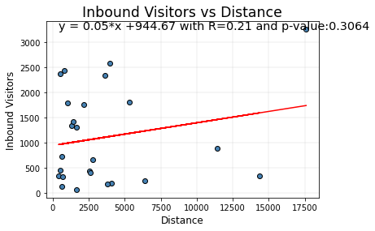

```
--------------------------------------------------------------------------------------
Weigth Average by Inbound Visitors
```

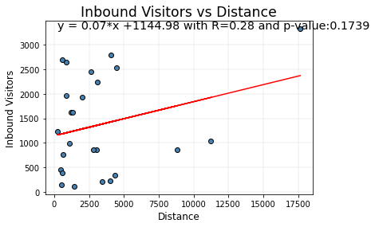

```python
#Using all observation of year
graphRegressSimple(tourismData['Distance'],tourismData['Inbound Visitors'])
#Usign mean
print(f'''--------------------------------------------------------------------------------------
Mean of Variable
''')
graphRegressSimple(MultilinearData['Distance'],MultilinearData['Inbound Visitors'])
#Usign weigth average
print(f'''--------------------------------------------------------------------------------------
Weigth Average by Inbound Visitors
''')
graphRegressSimple(MultilinearDataAvgW['Distance'],MultilinearDataAvgW['Inbound Visitors'])
```

### Cultural as explicative variable

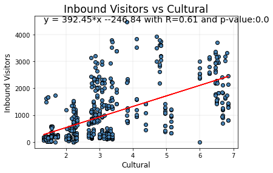

```
--------------------------------------------------------------------------------------
Mean of Variable
```

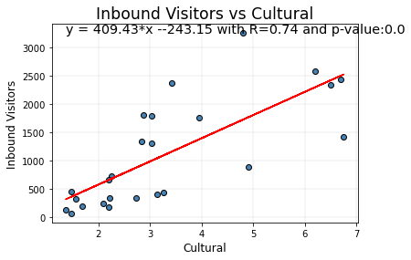

```
--------------------------------------------------------------------------------------
Weigth Average by Inbound Visitors
```

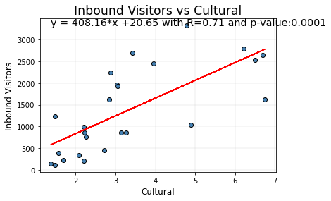

```python
#Using all observation of year
graphRegressSimple(tourismData['Cultural'],tourismData['Inbound Visitors'])
#Usign mean
print(f'''--------------------------------------------------------------------------------------
Mean of Variable
''')
graphRegressSimple(MultilinearData['Cultural'],MultilinearData['Inbound Visitors'])
#Usign weigth average
print(f'''--------------------------------------------------------------------------------------
Weigth Average by Inbound Visitors
''')
graphRegressSimple(MultilinearDataAvgW['Cultural'],MultilinearDataAvgW['Inbound Visitors'])
```

### Government prioritization as explicative variable

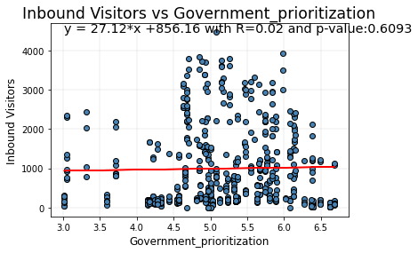

```
--------------------------------------------------------------------------------------
Mean of Variable
```

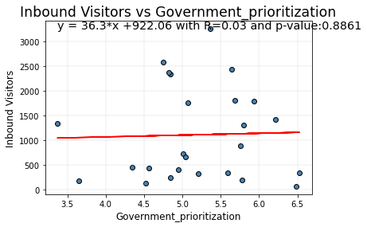

```
--------------------------------------------------------------------------------------
Weigth Average by Inbound Visitors
```

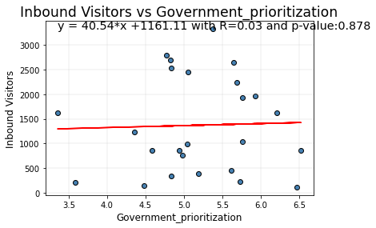

```python
#Using all observation of year
graphRegressSimple(tourismData['Government_prioritization'],tourismData['Inbound Visitors'])
#Usign mean
print(f'''--------------------------------------------------------------------------------------
Mean of Variable
''')
graphRegressSimple(MultilinearData['Government_prioritization'],MultilinearData['Inbound Visitors'])
#Usign weigth average
print(f'''--------------------------------------------------------------------------------------
Weigth Average by Inbound Visitors
''')
graphRegressSimple(MultilinearDataAvgW['Government_prioritization'],MultilinearDataAvgW['Inbound Visitors'])
```

### Segurity homocide as explicative variable

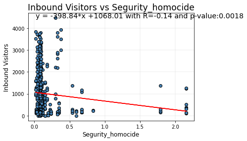

```
--------------------------------------------------------------------------------------
Mean of Variable
```

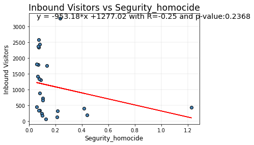

```
--------------------------------------------------------------------------------------
Weigth Average by Inbound Visitors
```

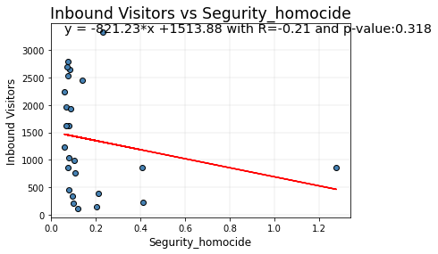

```python
#Using all observation of year
graphRegressSimple(tourismData['Segurity_homocide'],tourismData['Inbound Visitors'])
#Usign mean
print(f'''--------------------------------------------------------------------------------------
Mean of Variable
''')
graphRegressSimple(MultilinearData['Segurity_homocide'],MultilinearData['Inbound Visitors'])
#Usign weigth average
print(f'''--------------------------------------------------------------------------------------
Weigth Average by Inbound Visitors
''')
graphRegressSimple(MultilinearDataAvgW['Segurity_homocide'],MultilinearDataAvgW['Inbound Visitors'])
```

### Segurity terrorism as explicative variable

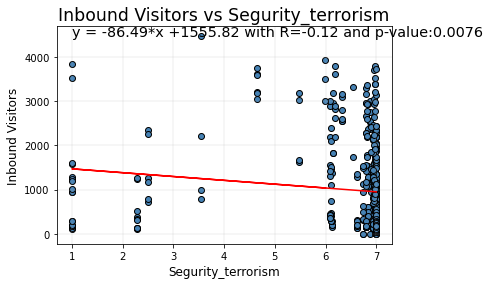

```
--------------------------------------------------------------------------------------
Mean of Variable
```

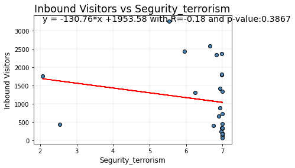

```
--------------------------------------------------------------------------------------
Weigth Average by Inbound Visitors
```

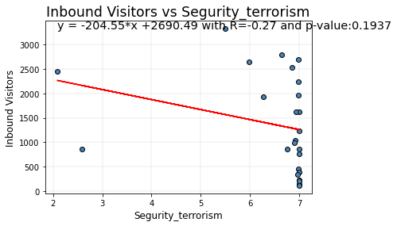

```python
#Using all observation of year
graphRegressSimple(tourismData['Segurity_terrorism'],tourismData['Inbound Visitors'])
#Usign mean
print(f'''--------------------------------------------------------------------------------------
Mean of Variable
''')
graphRegressSimple(MultilinearData['Segurity_terrorism'],MultilinearData['Inbound Visitors'])
#Usign weigth average
print(f'''--------------------------------------------------------------------------------------
Weigth Average by Inbound Visitors
''')
graphRegressSimple(MultilinearDataAvgW['Segurity_terrorism'],MultilinearDataAvgW['Inbound Visitors'])
```

### Natural resources as explicative variable

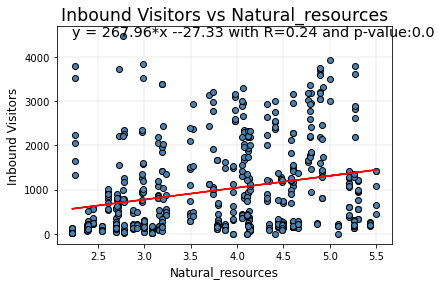

```
--------------------------------------------------------------------------------------
Mean of Variable
```

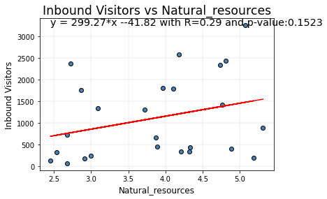

```
--------------------------------------------------------------------------------------
Weigth Average by Inbound Visitors
```

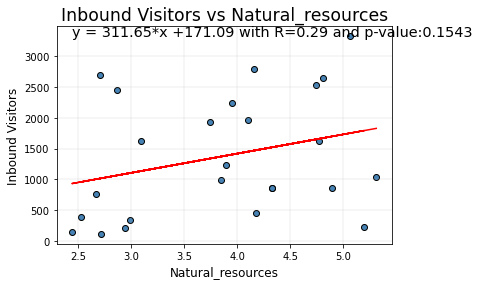

```python
#Using all observation of year
graphRegressSimple(tourismData['Natural_resources'],tourismData['Inbound Visitors'])
#Usign mean
print(f'''--------------------------------------------------------------------------------------
Mean of Variable
''')
graphRegressSimple(MultilinearData['Natural_resources'],MultilinearData['Inbound Visitors'])
#Usign weigth average
print(f'''--------------------------------------------------------------------------------------
Weigth Average by Inbound Visitors
''')
graphRegressSimple(MultilinearDataAvgW['Natural_resources'],MultilinearDataAvgW['Inbound Visitors'])
```

### Price competitiveness as explicative variable

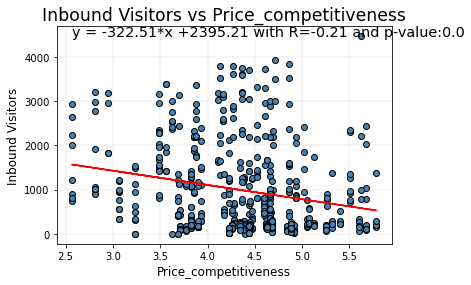

```
--------------------------------------------------------------------------------------
Mean of Variable
```

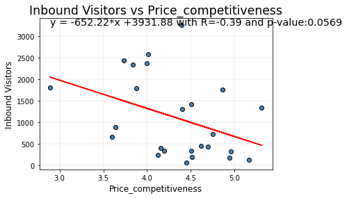

```
--------------------------------------------------------------------------------------
Weigth Average by Inbound Visitors
```

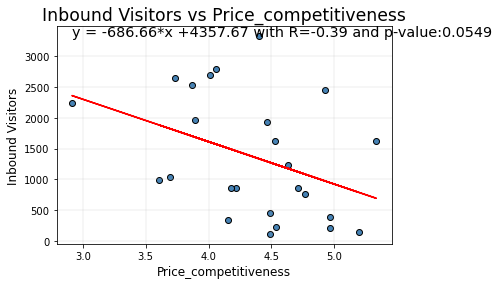

```python
#Using all observation of year
graphRegressSimple(tourismData['Price_competitiveness'],tourismData['Inbound Visitors'])
#Usign mean
print(f'''--------------------------------------------------------------------------------------
Mean of Variable
''')
graphRegressSimple(MultilinearData['Price_competitiveness'],MultilinearData['Inbound Visitors'])
#Usign weigth average
print(f'''--------------------------------------------------------------------------------------
Weigth Average by Inbound Visitors
''')
graphRegressSimple(MultilinearDataAvgW['Price_competitiveness'],MultilinearDataAvgW['Inbound Visitors'])
```

### Service infrastructure as explicative variable

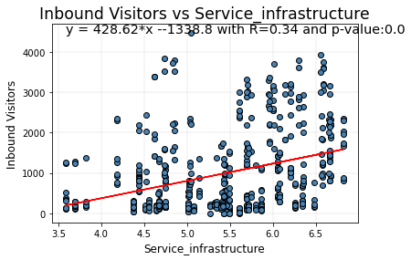

```
--------------------------------------------------------------------------------------
Mean of Variable
```

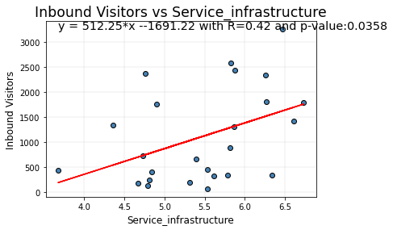

```
--------------------------------------------------------------------------------------
Weigth Average by Inbound Visitors
```

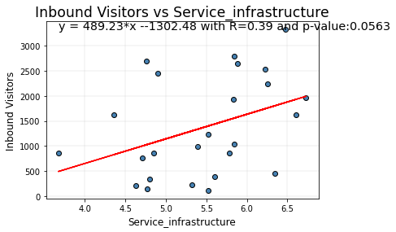

```python
#Using all observation of year
graphRegressSimple(tourismData['Service_infrastructure'],tourismData['Inbound Visitors'])
#Usign mean
print(f'''--------------------------------------------------------------------------------------
Mean of Variable
''')
graphRegressSimple(MultilinearData['Service_infrastructure'],MultilinearData['Inbound Visitors'])
#Usign weigth average
print(f'''--------------------------------------------------------------------------------------
Weigth Average by Inbound Visitors
''')
graphRegressSimple(MultilinearDataAvgW['Service_infrastructure'],MultilinearDataAvgW['Inbound Visitors'])
```

### Visa requirements as explicative variable

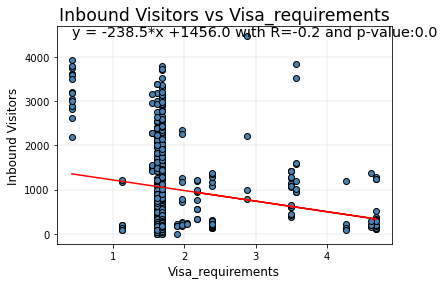

```
--------------------------------------------------------------------------------------
Mean of Variable
```

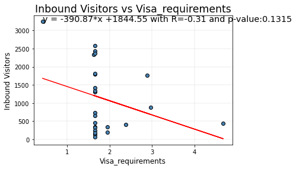

```
--------------------------------------------------------------------------------------
Weigth Average by Inbound Visitors
```

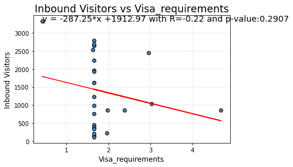

```python
#Using all observation of year
graphRegressSimple(tourismData['Visa_requirements'],tourismData['Inbound Visitors'])
#Usign mean
print(f'''--------------------------------------------------------------------------------------
Mean of Variable
''')
graphRegressSimple(MultilinearData['Visa_requirements'],MultilinearData['Inbound Visitors'])
#Usign weigth average
print(f'''--------------------------------------------------------------------------------------
Weigth Average by Inbound Visitors
''')
graphRegressSimple(MultilinearDataAvgW['Visa_requirements'],MultilinearDataAvgW['Inbound Visitors'])
```

## Linear Models

In this section, we used linear models using multiple variables to have a model which adapts better to the aviable data.

##### Model 1

$Tourism $=$f$ ($distance$,$culture$,$GP$,$SH$,$ST$,$NR$,$PC$,$SI$,$VR$)

##### Model 2

$Tourism $=$f$ ($distance$,$culture$,$NR$,$SI$)

##### Model 3

$Tourism $=$f$ ($culture$,$NR$,$SI$)

##### Model 4

$Tourism $=$f$ ($culture$,$NR$)

where

$distance$= Indicate how far are two contries by kilometers

$culture$= The index of cultural resources and business 7 indicate more offer of cultural resources while 1 indicate less offer of cultural resources

$GP$= The index Government prioritization of the travel & tourism industry 7 indicate top priority while 1 indicate no priority at all

$SH$= The index Homicide rate 7 less number of homocide per 100,000 population while 1 less number of homocide per 100,000 population

$ST$= The Index of terrorism incidence 7 indicate no attack while 1 most attacks or casualities

$NR$= Natural Resources 7 indicate more offer of natural resources while 1 indicate less offer

$PC$= Price competitiveness 7 indicate more price competitiviness while 1 less price competitiviness

$SI$= The transport infraestructura 7 indicate more developet infraestructure while 1 less develop infraestructure

$VR$= Visa requirements two countries 7 less requirements while 1 more requirements

### Using mean by Contries

```python
#Variables using the data aviable Model 1
X=MultilinearData[['Distance','Cultural','Government_prioritization','Segurity_homocide','Segurity_terrorism','Natural_resources','Price_competitiveness','Service_infrastructure','Visa_requirements']]
y=MultilinearData['Inbound Visitors']
#Variables using distance and lienar regression significant Model 2
X2=MultilinearData[['Distance','Cultural','Natural_resources','Service_infrastructure']]
y2=MultilinearData['Inbound Visitors']
#Variables using lienar regression significant Model 3
X3=MultilinearData[['Cultural','Natural_resources','Service_infrastructure']]
y3=MultilinearData['Inbound Visitors']

#Variables using lienar regression significant Model 4
X4=MultilinearData[['Cultural','Natural_resources']]
y4=MultilinearData['Inbound Visitors']


#To train and test Model 1
XTrain, XTest, yTrain, yTest=train_test_split(X,y, random_state=0)

#To train and test Model 2
X2Train, X2Test, y2Train, y2Test=train_test_split(X2,y2, random_state=0)

#To train and test Model 3
X3Train, X3Test, y3Train, y3Test=train_test_split(X3,y3, random_state=0)

#To train and test Model 4
X4Train, X4Test, y4Train, y4Test=train_test_split(X4,y4, random_state=0)
```

```python
def ResultsModel(X_Train, X_Test, y_Train, y_Test,X_var):
    XTrain=X_Train
    XTest=X_Test
    yTrain=y_Train
    yTest=y_Test
    try:
        X=list(X_var.columns)
    except:
        X=list(X_var.name)
    #Compute linear model
    modelMultilinar=linear_model.LinearRegression().fit(XTrain,yTrain)
    yPredict=modelMultilinar.predict(XTest)
    predict=yPredict
    compare=(predict-yTest)
    R2=r2_score(yTest, yPredict)

    #Have the data frame with the result of model
    var=X
    coef=list(modelMultilinar.coef_)
    var.append('Intercept')
    coef.append(modelMultilinar.intercept_)


    Params=pd.DataFrame({
    'Variables':var,
    'Coeficientes':coef
    })



    return Params
```

```python
 def graphModelResults(X_Train, X_Test, y_Train, y_Test):

    XTrain=X_Train
    XTest=X_Test
    yTrain=y_Train
    yTest=y_Test

    #Compute linear model
    modelMultilinar=linear_model.LinearRegression().fit(XTrain,yTrain)
    yPredict=modelMultilinar.predict(XTest)
    predict=yPredict
    compare=(predict-yTest)
    R2=r2_score(yTest, yPredict)

    #Graph
    plt.scatter(predict,compare, color='black', marker='o', facecolor='steelblue')
    plt.title(f'Predictions vs Real Data', fontsize='xx-large')
    plt.hlines(y=0, xmin=predict.min(), xmax=predict.max(), color='red')


    return print(round(R2,3)), plt.show()
```

##### Results of Model 1

$Tourism $=$f$ ($distance$,$culture$,$GP$,$SH$,$ST$,$NR$,$PC$,$SI$,$VR$)

```python
ResultsModel(XTrain, XTest, yTrain, yTest,X)
```

|  | Variables | Coeficientes |
| --- | --- | --- |
| 0 | Distance | 0.010336 |
| 1 | Cultural | 315.138313 |
| 2 | Government_prioritization | -475.201172 |
| 3 | Segurity_homocide | 1177.912304 |
| 4 | Segurity_terrorism | -324.055601 |
| 5 | Natural_resources | -213.611314 |
| 6 | Price_competitiveness | -868.508977 |
| 7 | Service_infrastructure | 213.370604 |
| 8 | Visa_requirements | -746.058687 |
| 9 | Intercept | 9350.980177 |

```
0.382
```

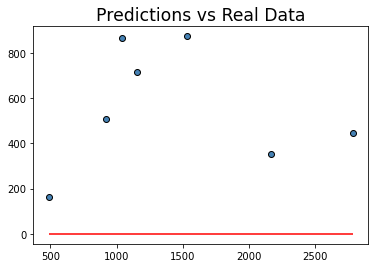

```
(None, None)
```

```python
graphModelResults(XTrain, XTest, yTrain, yTest)
```

##### Results of Model 2

$Tourism $=$f$ ($distance$,$culture$,$NR$,$SI$)

```python
ResultsModel(X2Train, X2Test, y2Train, y2Test,X2)
```

|  | Variables | Coeficientes |
| --- | --- | --- |
| 0 | Distance | 0.039822 |
| 1 | Cultural | 465.498090 |
| 2 | Natural_resources | -349.981024 |
| 3 | Service_infrastructure | 117.147987 |
| 4 | Intercept | 160.108732 |

```
0.7
```

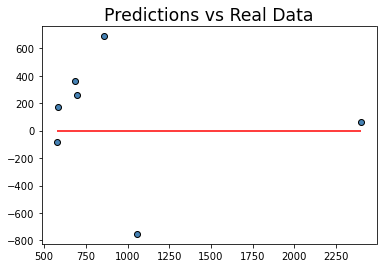

```
(None, None)
```

```python
graphModelResults(X2Train, X2Test, y2Train, y2Test)
```

##### Results of Model 3

$Tourism $=$f$ ($culture$,$NR$,$SI$)

```python
ResultsModel(X3Train, X3Test, y3Train, y3Test,X3)
```

|  | Variables | Coeficientes |
| --- | --- | --- |
| 0 | Cultural | 449.203862 |
| 1 | Natural_resources | -207.656277 |
| 2 | Service_infrastructure | 76.384014 |
| 3 | Intercept | 52.244269 |

```
0.638
```

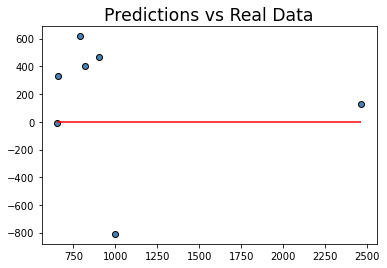

```
(None, None)
```

```python
graphModelResults(X3Train, X3Test, y3Train, y3Test)
```

##### Results of Model 4

$Tourism $=$f$ ($culture$,$NR$)

```python
ResultsModel(X4Train, X4Test, y4Train, y4Test,X4)
```

|  | Variables | Coeficientes |
| --- | --- | --- |
| 0 | Cultural | 452.951971 |
| 1 | Natural_resources | -171.361390 |
| 2 | Intercept | 324.887811 |

```
0.557
```

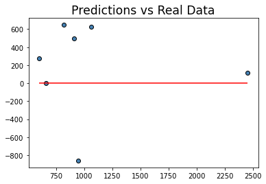

```
(None, None)
```

```python
graphModelResults(X4Train, X4Test, y4Train, y4Test)
```